# Data_Visualisation_Graded_Questions

## Data Visualisation - Graded Questions

`Note` - *This stub file doesn't contain the conceptual questions asked on the platform*

### I) Marks Analysis

In the **'Marks.csv'** file, you can find the scores obtained by 200 students in 4 subjects of a standardised test. The different columns - `Score A`, `Score B`, `Score C` and `Score D` indicate the score obtained by a particular student in the respective subjects A, B, C and D.

Load the dataset to your notebook and answer the following questions

```python
#Load the necessary Libraries
import pandas as pd
import numpy as np
import seaborn as sns
import matplotlib.pyplot as plt
```

```python
#Load the dataset
df1 = pd.read_csv('Marks.csv')
df1.head()
```

|  | Score A | Score B | Score C | Score D |
| --- | --- | --- | --- | --- |
| 0 | 230.1 | 37.8 | 69.2 | 22.1 |
| 1 | 44.5 | 39.3 | 45.1 | 10.4 |
| 2 | 17.2 | 45.9 | 69.3 | 12.0 |
| 3 | 151.5 | 41.3 | 58.5 | 16.5 |
| 4 | 180.8 | 10.8 | 58.4 | 17.9 |

**Q1)** Load the dataset and plot a histogram for the `Score A` column by keeping the `number of bins to 6`. Which bin range among the following has the highest frequency?

(`Note` - *The bin ranges mentioned in the options are approximate values for the bin ranges that you'll actually get when you plot the histogram*)

```
a)0-50
b)50-100
c)150-200
d)200-250
```

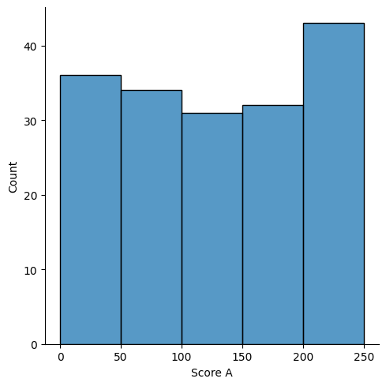

```python
#Your code here
sns.displot(df1, x="Score A", bins = [0,50,100,150,200,250])
```

**Q2)** Plot a box plot for the column `Score C` and choose the correct option.

```
A - The 25th percentile lies between 20 and 40
B - The 75th percentile lies between 40 and 60
C - The 25th percentile lies between 0 and 20
D - Both B and C (Correct answer)
```

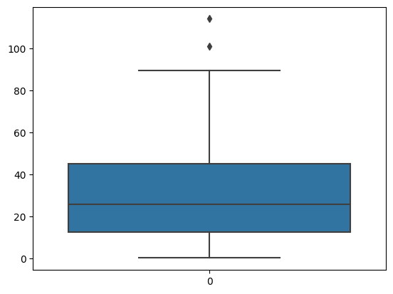

```python
#Your code here
sns.boxplot(df1['Score C'])
```

### II) Superstore Data

In the `superstore.csv` file, you have the details of orders purchased in an American online retail store. Load the dataset, observe and analyse the different columns and answer the following questions.

```python
#Load the dataset
df2 = pd.read_csv('superstore.csv')
df2.head()
```

|  | Order ID | Ship Mode | Segment | Region | Product ID | Sales | Quantity | Discount | Profit |
| --- | --- | --- | --- | --- | --- | --- | --- | --- | --- |
| 0 | CA-2016-152156 | Second Class | Consumer | South | FUR-BO-10001798 | 261.9600 | 2 | 0% | 41.9136 |
| 1 | CA-2016-152156 | Second Class | Consumer | South | FUR-CH-10000454 | 731.9400 | 3 | 0% | 219.5820 |
| 2 | CA-2016-138688 | Second Class | Corporate | West | OFF-LA-10000240 | 14.6200 | 2 | 0% | 6.8714 |
| 3 | US-2015-108966 | Standard Class | Consumer | South | FUR-TA-10000577 | 957.5775 | 5 | 0.45% | -383.0310 |
| 4 | US-2015-108966 | Standard Class | Consumer | South | OFF-ST-10000760 | 22.3680 | 2 | 0.20% | 2.5164 |

**Q4)** Plot a pie-chart to find the Ship Mode through which most of the orders are being delivered.

[output not shown]

[output not shown]

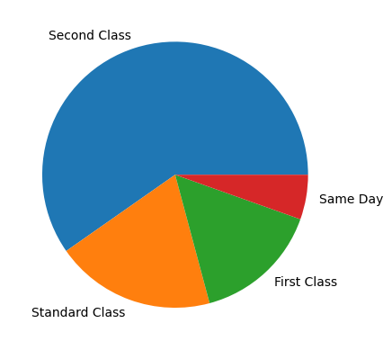

```python
#Your code here
plt.pie(df2['Ship Mode'].value_counts(),labels=df2['Ship Mode'].unique())
```

**Q5)** Plot a bar chart comparing the average `Discount` across all the `Regions` and report back the `Region` getting the highest average discount

**Note** - You need to clean the `Discount` column first

```
a)Central (Correct answer)
b)South
c)West
d)East
```

```python
df2['Discount'] = df2['Discount'].str.replace('%','')
df2['Discount'] = df2['Discount'].astype(float)
df2.head()
```

|  | Order ID | Ship Mode | Segment | Region | Product ID | Sales | Quantity | Discount | Profit |
| --- | --- | --- | --- | --- | --- | --- | --- | --- | --- |
| 0 | CA-2016-152156 | Second Class | Consumer | South | FUR-BO-10001798 | 261.9600 | 2 | 0.00 | 41.9136 |
| 1 | CA-2016-152156 | Second Class | Consumer | South | FUR-CH-10000454 | 731.9400 | 3 | 0.00 | 219.5820 |
| 2 | CA-2016-138688 | Second Class | Corporate | West | OFF-LA-10000240 | 14.6200 | 2 | 0.00 | 6.8714 |
| 3 | US-2015-108966 | Standard Class | Consumer | South | FUR-TA-10000577 | 957.5775 | 5 | 0.45 | -383.0310 |
| 4 | US-2015-108966 | Standard Class | Consumer | South | OFF-ST-10000760 | 22.3680 | 2 | 0.20 | 2.5164 |

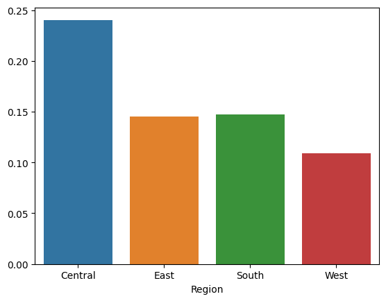

```python
avg = df2.groupby('Region')['Discount'].mean()
sns.barplot(x = avg.index,y = avg.values)
```